# Reproducible Research: Peer Assessment 1

## Loading and preprocessing the data

This file assumes that the data set is unzipped in the same location as the source file (this file). Make sure to set your working directory.

First, let’s read in the data file:

```r
activity_data <- read.csv('activity.csv', header=TRUE)
head(activity_data)
```

```
##   steps       date interval
## 1    NA 2012-10-01        0
## 2    NA 2012-10-01        5
## 3    NA 2012-10-01       10
## 4    NA 2012-10-01       15
## 5    NA 2012-10-01       20
## 6    NA 2012-10-01       25
```

Now it’s read in, we want to make sure that each of the variables (columns) is in the appropriate form (i.e. data type). Let’s take a look at what we have:

```r
summary(activity_data)
```

```
##      steps               date          interval
##  Min.   :  0.0   2012-10-01:  288   Min.   :   0
##  1st Qu.:  0.0   2012-10-02:  288   1st Qu.: 589
##  Median :  0.0   2012-10-03:  288   Median :1178
##  Mean   : 37.4   2012-10-04:  288   Mean   :1178
##  3rd Qu.: 12.0   2012-10-05:  288   3rd Qu.:1766
##  Max.   :806.0   2012-10-06:  288   Max.   :2355
##  NA's   :2304    (Other)   :15840
```

```r
class(activity_data$steps)
```

```
## [1] "integer"
```

```r
class(activity_data$date)
```

```
## [1] "factor"
```

```r
class(activity_data$interval)
```

```
## [1] "integer"
```

So we can see that steps and interval are integers, which is great. However, the date variable would be more suitable as an actual date/time type for our analysis later.

Let’s convert it:

```r
activity_data$date <- as.Date(activity_data$date)
class(activity_data$date)
```

```
## [1] "Date"
```

```r
summary(activity_data)
```

```
##      steps            date               interval
##  Min.   :  0.0   Min.   :2012-10-01   Min.   :   0
##  1st Qu.:  0.0   1st Qu.:2012-10-16   1st Qu.: 589
##  Median :  0.0   Median :2012-10-31   Median :1178
##  Mean   : 37.4   Mean   :2012-10-31   Mean   :1178
##  3rd Qu.: 12.0   3rd Qu.:2012-11-15   3rd Qu.:1766
##  Max.   :806.0   Max.   :2012-11-30   Max.   :2355
##  NA's   :2304
```

Finally, let’s convert it to a data table for some easy grouping later. Note: you’ll need the data.table package.

```r
library(data.table)
activity_dt <- data.table(activity_data)
```

## What is mean total number of steps taken per day?

Okay, now everything is loaded nicely, let’s find the mean total number of steps and print it:

```r
daily_steps <- activity_dt[,list(steps=sum(steps)),by=date]
head(daily_steps)
```

```
##          date steps
## 1: 2012-10-01    NA
## 2: 2012-10-02   126
## 3: 2012-10-03 11352
## 4: 2012-10-04 12116
## 5: 2012-10-05 13294
## 6: 2012-10-06 15420
```

```r
mean_steps <- mean(daily_steps$steps)
mean_steps
```

```
## [1] NA
```

But, we can see that the NAs are causing problems. Let’s ignore them for now:

```r
mean_steps <- mean(daily_steps$steps, na.rm=TRUE)
mean_steps
```

```
## [1] 10766
```

Now we can see that the mean is actually 1.0766 × 10<sup>4</sup>. Similarly, let’s look at a histogram of daily steps as well as the median.

```r
median_steps <- median(daily_steps$steps, na.rm=TRUE)
median_steps
```

```
## [1] 10765
```

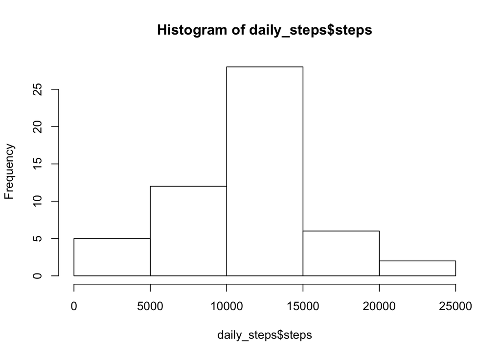

```r
hist(daily_steps$steps)
```

## What is the average daily activity pattern?

To look at the daily activity pattern, let’s first group the average steps by interval. Note that looking at the data, we have matching intervals on each day, so we can just group these in our data table. Then we can plot the time series as follows:

```r
interval_series <- activity_dt[,list(steps=mean(steps, na.rm=TRUE)),by=interval]
head(interval_series)
```

```
##    interval   steps
## 1:        0 1.71698
## 2:        5 0.33962
## 3:       10 0.13208
## 4:       15 0.15094
## 5:       20 0.07547
## 6:       25 2.09434
```

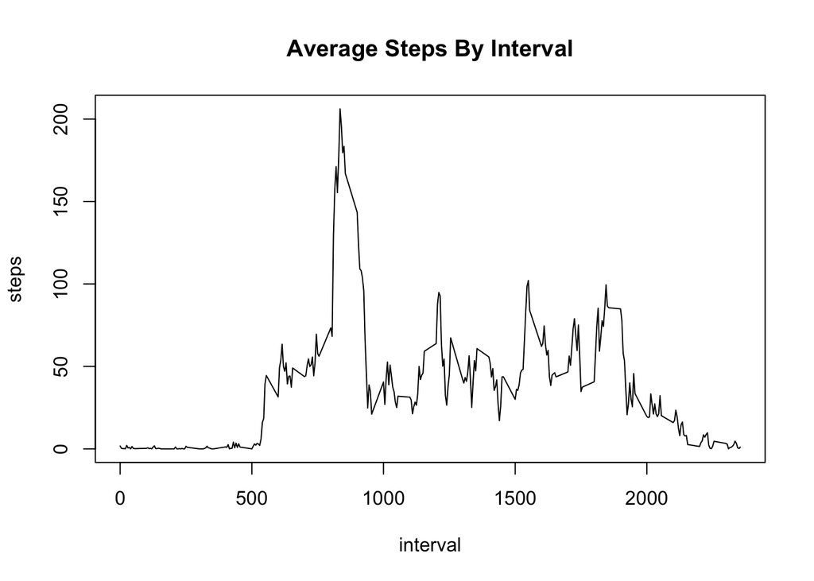

```r
plot(steps ~ interval, data=interval_series, type ='l')
title(main='Average Steps By Interval')
```

Using our series, we can find the max average interval and plot a line to show it.

```r
max_interval <- interval_series[which.max(interval_series$steps),]
max_interval
```

```
##    interval steps
## 1:      835 206.2
```

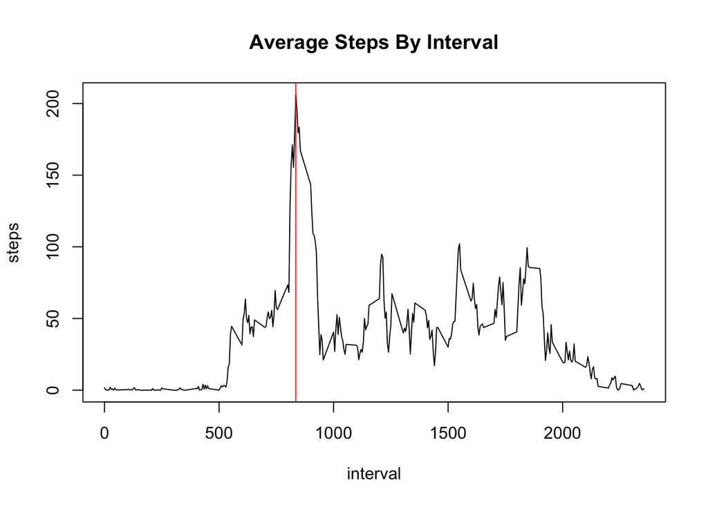

```r
plot(steps ~ interval, data=interval_series, type ='l')
title(main='Average Steps By Interval')
abline(v=max_interval$interval, col='red')
```

So, we see that the max interval is at 835. If we knew that the 0 interval was midnight, we could find the corresponding time period.

## Imputing missing values

First, let’s look at a summary of the original data set to look for NAs.

```r
summary(activity_data)
```

```
##      steps            date               interval
##  Min.   :  0.0   Min.   :2012-10-01   Min.   :   0
##  1st Qu.:  0.0   1st Qu.:2012-10-16   1st Qu.: 589
##  Median :  0.0   Median :2012-10-31   Median :1178
##  Mean   : 37.4   Mean   :2012-10-31   Mean   :1178
##  3rd Qu.: 12.0   3rd Qu.:2012-11-15   3rd Qu.:1766
##  Max.   :806.0   Max.   :2012-11-30   Max.   :2355
##  NA's   :2304
```

So it looks like date and interval are clean, but steps has 2304 NA values. We can impute the missing data using the median for the corresponding interval.

```r
interval_medians <- activity_dt[,list(steps=median(steps, na.rm=TRUE)),by=interval]
cleaned_data <- activity_data
for (i in 1:nrow(cleaned_data)) {
        observation <- cleaned_data[i,]
        if (is.na(observation$steps)) {
                imputed <- interval_medians[interval_medians$interval == observation$interval,][1,]$steps
                cleaned_data[i,]$steps <- imputed
        }
}
summary(activity_data)
```

```
##      steps            date               interval
##  Min.   :  0.0   Min.   :2012-10-01   Min.   :   0
##  1st Qu.:  0.0   1st Qu.:2012-10-16   1st Qu.: 589
##  Median :  0.0   Median :2012-10-31   Median :1178
##  Mean   : 37.4   Mean   :2012-10-31   Mean   :1178
##  3rd Qu.: 12.0   3rd Qu.:2012-11-15   3rd Qu.:1766
##  Max.   :806.0   Max.   :2012-11-30   Max.   :2355
##  NA's   :2304
```

```r
summary(cleaned_data)
```

```
##      steps          date               interval
##  Min.   :  0   Min.   :2012-10-01   Min.   :   0
##  1st Qu.:  0   1st Qu.:2012-10-16   1st Qu.: 589
##  Median :  0   Median :2012-10-31   Median :1178
##  Mean   : 33   Mean   :2012-10-31   Mean   :1178
##  3rd Qu.:  8   3rd Qu.:2012-11-15   3rd Qu.:1766
##  Max.   :806   Max.   :2012-11-30   Max.   :2355
```

So now we have imputed the data, let’s repeat the mean, median, histogram work.

```r
clean_dt <- data.table(cleaned_data)
daily_steps_clean <- clean_dt[,list(steps=sum(steps)),by=date]
mean_steps_clean <- mean(daily_steps_clean$steps)
mean_steps_clean
```

```
## [1] 9504
```

```r
median_steps_clean <- median(daily_steps_clean$steps)
median_steps_clean
```

```
## [1] 10395
```

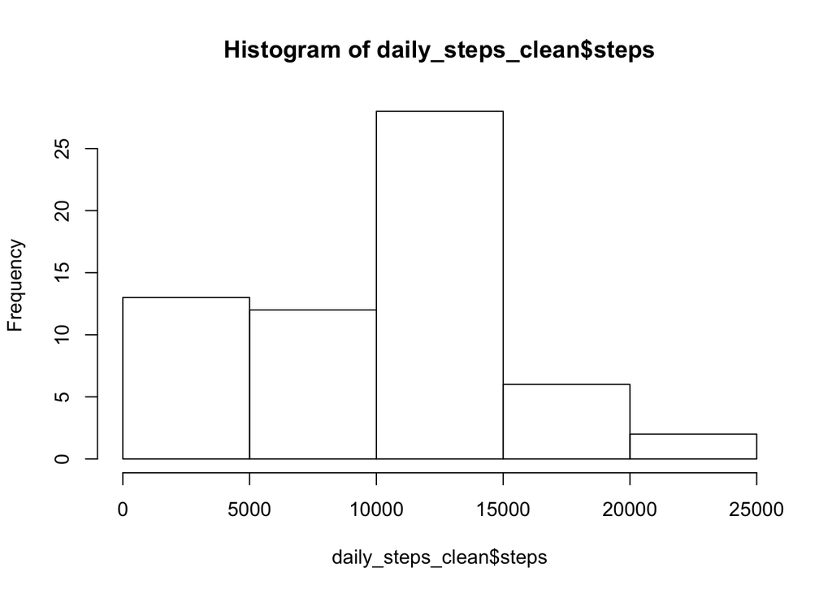

```r
hist(daily_steps_clean$steps)
```

So we can see that mean, median and distribution has changed rather dramatically with the imputed data. The mean and median hae decreased, with an increase of days with fewer steps and corresponding skew of the distribution to the left.

## Are there differences in activity patterns between weekdays and weekends?

To look for differences between weekdays and weekends, we need to first tag each day as a weekday or weekend. We can then create our interval summary and plot it.

```r
get_weekday <- function(date) {
        ifelse (weekdays(date) == 'Saturday' | weekdays(date) == 'Sunday',
                'Weekend', 'Weekday')
}
cleaned_data$day <- as.factor(get_weekday(as.Date(cleaned_data$date)))
summary(cleaned_data)
```

```
##      steps          date               interval         day
##  Min.   :  0   Min.   :2012-10-01   Min.   :   0   Weekday:12960
##  1st Qu.:  0   1st Qu.:2012-10-16   1st Qu.: 589   Weekend: 4608
##  Median :  0   Median :2012-10-31   Median :1178
##  Mean   : 33   Mean   :2012-10-31   Mean   :1178
##  3rd Qu.:  8   3rd Qu.:2012-11-15   3rd Qu.:1766
##  Max.   :806   Max.   :2012-11-30   Max.   :2355
```

```r
cleaned_dt <- data.table(cleaned_data)
day_interval_series <- cleaned_dt[,list(steps=mean(steps, na.rm=TRUE)),by=list(interval,day)]
head(day_interval_series)
```

```
##    interval     day   steps
## 1:        0 Weekday 2.02222
## 2:        5 Weekday 0.40000
## 3:       10 Weekday 0.15556
## 4:       15 Weekday 0.17778
## 5:       20 Weekday 0.08889
## 6:       25 Weekday 1.31111
```

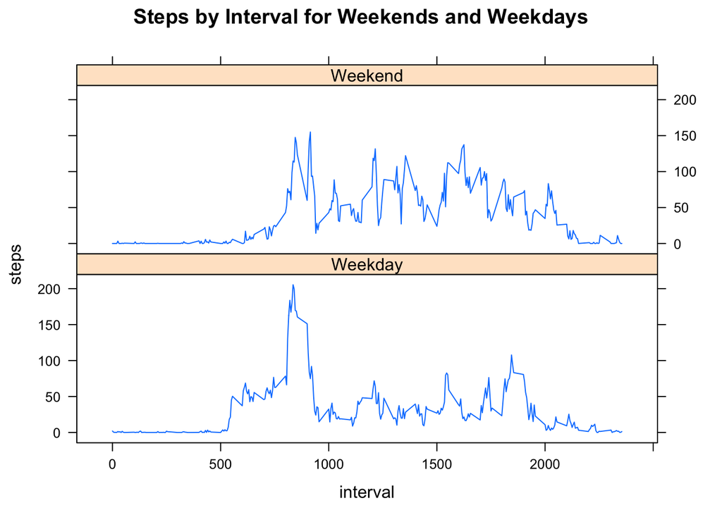

```r
library(lattice)
xyplot(steps ~ interval | day, data=day_interval_series, type='l', layout=c(1,2),
       main="Steps by Interval for Weekends and Weekdays")
```

So from the plots, we can see that there is a higher peak period during weekdays, but more consistent activity over weekends.